# R Notebook

**Libraries**

```r
library(FactoMineR)
library(tidyr)
library(dplyr)
library(tidyverse)
library(magrittr)
library(ggplot2)
library(ggpubr)
library(factoextra)
library(gridExtra)
library(moments)
```

**Screw Caps Data**

```r
raw_data <- read.table("ScrewCaps.csv",header=TRUE, sep=",", dec=".", row.names=1)
head(raw_data)
```

|  | Supplier | Diameter | weight | nb.of.pieces | Shape | Impermeability | Finishing | Mature.Volume | Raw.Material | Price | Length |
| --- | --- | --- | --- | --- | --- | --- | --- | --- | --- | --- | --- |
| 1 | Supplier A | 3.780 | 3.780 | 2 | Shape 1 | Type 1 | Lacquering | 60000 | PS | 28.19338 | 30.118312 |
| 2 | Supplier A | 3.994 | 4.768 | 3 | Shape 2 | Type 2 | Lacquering | 49000 | PS | 35.34190 | 31.693726 |
| 3 | Supplier A | 3.994 | 4.768 | 3 | Shape 2 | Type 2 | Lacquering | 55000 | PS | 41.94724 | 31.738166 |
| 4 | Supplier A | 1.066 | 1.917 | 4 | Shape 2 | Type 2 | Lacquering | 1500 | PS | 26.76473 | 8.472485 |
| 5 | Supplier A | 1.179 | 1.261 | 5 | Shape 3 | Type 1 | Hot Printing | 215000 | PP | 13.84152 | 9.222997 |
| 6 | Supplier A | 1.079 | 1.250 | 5 | Shape 2 | Type 1 | Hot Printing | 75000 | PP | 16.02589 | 8.764609 |

```r
summary(raw_data)
```

```
       Supplier      Diameter          weight       nb.of.pieces        Shape     Impermeability        Finishing   Mature.Volume    Raw.Material     Price
 Supplier A: 31   Min.   :0.4458   Min.   :0.610   Min.   : 2.000   Shape 1:134   Type 1:172     Hot Printing: 62   Min.   :  1000   ABS: 21      Min.   : 6.477
 Supplier B:150   1st Qu.:0.7785   1st Qu.:1.083   1st Qu.: 3.000   Shape 2: 45   Type 2: 23     Lacquering  :133   1st Qu.: 15000   PP :148      1st Qu.:11.807
 Supplier C: 14   Median :1.0120   Median :1.400   Median : 4.000   Shape 3:  8                                     Median : 45000   PS : 26      Median :14.384
                  Mean   :1.2843   Mean   :1.701   Mean   : 4.113   Shape 4:  8                                     Mean   : 96930                Mean   :16.444
                  3rd Qu.:1.2886   3rd Qu.:1.704   3rd Qu.: 5.000                                                   3rd Qu.:115000                3rd Qu.:18.902
                  Max.   :5.3950   Max.   :7.112   Max.   :10.000                                                   Max.   :800000                Max.   :46.610
     Length
 Min.   : 3.369
 1st Qu.: 6.161
 Median : 8.086
 Mean   :10.247
 3rd Qu.:10.340
 Max.   :43.359
```

**2) We start with univariate and bivariate descriptive statistics. Using appropriate plot(s) or summaries answer the following questions.**

*a) How is the distribution of the Price? Comment your plot with respect to the quartiles of the Price.*

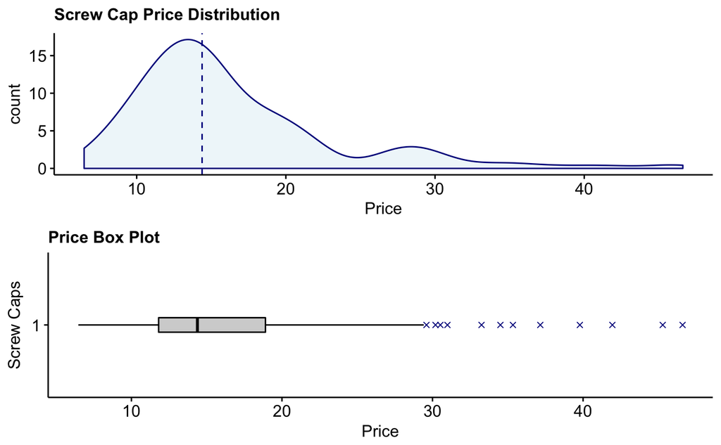

```r
price_density <- ggdensity(raw_data,x="Price",y = "..count..",
                        color="darkblue",
                        fill="lightblue",size=0.5,
                        alpha=0.2,
                        title = "Screw Cap Price Distribution",
                        linetype = "solid", add = c("median"))+ font("title", size = 12,face="bold")

price_boxplot <- ggboxplot(raw_data$Price, width = 0.1, fill ="lightgray", outlier.colour = "darkblue", outlier.shape=4.2, ylab = "Price", xlab = "Screw Caps" , title = "Price Box Plot") + rotate() + font("title", size = 12,face="bold")
price_quantile <- quantile(raw_data$Price)
ggarrange(price_density, price_boxplot, ncol = 1, nrow = 2)
```

```r
price_quantile
```

```
       0%       25%       50%       75%      100%
 6.477451 11.807022 14.384413 18.902429 46.610372
```

```r
skewness(raw_data$Price)
```

```
[1] 1.706151
```

```r
kurtosis(raw_data$Price)
```

```
[1] 6.395453
```

*b) Does the Price depend on the Length? weight?*

We examine Price vs. Length, log(Price) vs. log(Length); Price vs. weight, log(Price) vs. log(weight) and provide the summary for each.

The plots suggest somewhat of a relationship between the variables, but observing the results of the F and T tests confirm this to a high degree of significance.

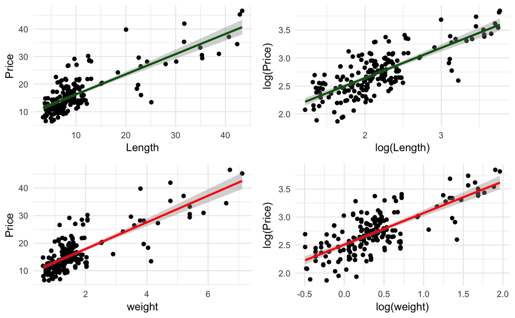

```r
price_length <- ggplot(raw_data, aes(x=Length, y=Price)) + geom_point() + geom_smooth(method=lm, color="darkgreen")+ theme_minimal()
price_length_log <- ggplot(raw_data, aes(x=log(Length), y=log(Price))) + geom_point() + geom_smooth(method=lm, color="darkgreen")+ theme_minimal()
price_weight <- ggplot(raw_data, aes(x=weight, y=Price)) + geom_point() + geom_smooth(method=lm,color="red")+theme_minimal()
price_weight_log <- ggplot(raw_data, aes(x=log(weight), y=log(Price))) + geom_point() + geom_smooth(method=lm,color="red")+theme_minimal()
ggarrange(ggarrange(price_length, price_length_log, ncol = 2, nrow = 1), ggarrange(price_weight, price_weight_log, ncol = 2, nrow = 1), ncol = 1, nrow = 2)
```

```r
summary(lm(formula = Price ~ Length, raw_data))
```

```
Call:
lm(formula = Price ~ Length, data = raw_data)

Residuals:
    Min      1Q  Median      3Q     Max
-13.901  -2.854  -0.741   1.931  16.181

Coefficients:
            Estimate Std. Error t value Pr(>|t|)
(Intercept)  8.94613    0.50918   17.57   <2e-16 ***
Length       0.73168    0.03953   18.51   <2e-16 ***
---
Signif. codes:  0 ‘***’ 0.001 ‘**’ 0.01 ‘*’ 0.05 ‘.’ 0.1 ‘ ’ 1

Residual standard error: 4.308 on 193 degrees of freedom
Multiple R-squared:  0.6397,    Adjusted R-squared:  0.6378
F-statistic: 342.6 on 1 and 193 DF,  p-value: < 2.2e-16
```

```r
summary(lm(formula = log(Price) ~ log(Length), raw_data))
```

```
Call:
lm(formula = log(Price) ~ log(Length), data = raw_data)

Residuals:
     Min       1Q   Median       3Q      Max
-0.70368 -0.15501 -0.01661  0.15170  0.59211

Coefficients:
            Estimate Std. Error t value Pr(>|t|)
(Intercept)  1.56380    0.07278   21.49   <2e-16 ***
log(Length)  0.53875    0.03282   16.42   <2e-16 ***
---
Signif. codes:  0 ‘***’ 0.001 ‘**’ 0.01 ‘*’ 0.05 ‘.’ 0.1 ‘ ’ 1

Residual standard error: 0.2466 on 193 degrees of freedom
Multiple R-squared:  0.5827,    Adjusted R-squared:  0.5805
F-statistic: 269.5 on 1 and 193 DF,  p-value: < 2.2e-16
```

```r
summary(lm(formula = Price ~ weight, raw_data))
```

```
Call:
lm(formula = Price ~ weight, data = raw_data)

Residuals:
     Min       1Q   Median       3Q      Max
-14.7993  -2.6207  -0.6631   2.5396  13.8357

Coefficients:
            Estimate Std. Error t value Pr(>|t|)
(Intercept)   8.2275     0.5602   14.69   <2e-16 ***
weight        4.8312     0.2718   17.78   <2e-16 ***
---
Signif. codes:  0 ‘***’ 0.001 ‘**’ 0.01 ‘*’ 0.05 ‘.’ 0.1 ‘ ’ 1

Residual standard error: 4.419 on 193 degrees of freedom
Multiple R-squared:  0.6208,    Adjusted R-squared:  0.6189
F-statistic:   316 on 1 and 193 DF,  p-value: < 2.2e-16
```

```r
summary(lm(formula = log(Price) ~ log(weight), raw_data))
```

```
Call:
lm(formula = log(Price) ~ log(weight), data = raw_data)

Residuals:
     Min       1Q   Median       3Q      Max
-0.71123 -0.15340 -0.01343  0.17735  0.69552

Coefficients:
            Estimate Std. Error t value Pr(>|t|)
(Intercept)  2.50618    0.02333  107.42   <2e-16 ***
log(weight)  0.56453    0.03718   15.18   <2e-16 ***
---
Signif. codes:  0 ‘***’ 0.001 ‘**’ 0.01 ‘*’ 0.05 ‘.’ 0.1 ‘ ’ 1

Residual standard error: 0.2577 on 193 degrees of freedom
Multiple R-squared:  0.5443,    Adjusted R-squared:  0.5419
F-statistic: 230.5 on 1 and 193 DF,  p-value: < 2.2e-16
```

*c) Does the Price depend on the Impermeability? Shape?*

The plots below suggests there is dependency on Impermeability - the medians differ significantly.

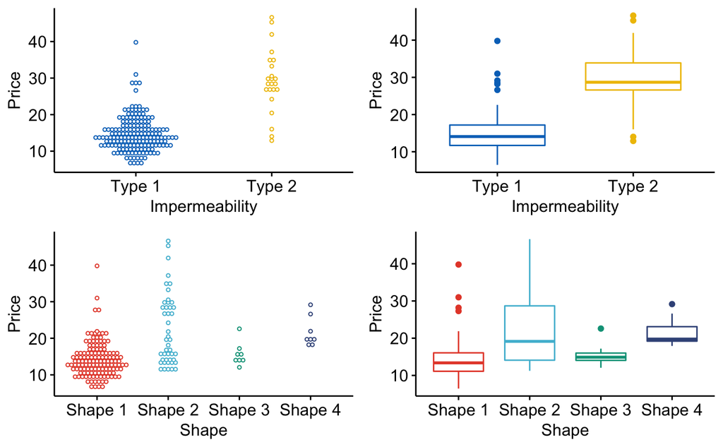

```r
impermability_plot_1 <- ggdotplot(raw_data,x="Impermeability",y="Price",color = "Impermeability", palette = "jco",binwidth = 1,legend="none")
shape_plot_1 <- ggdotplot(raw_data,x="Shape",y="Price",color = "Shape", palette = "npg",binwidth = 1,legend="none")
impermability_plot_2 <- ggboxplot(raw_data,x="Impermeability",y="Price",color = "Impermeability", palette = "jco",legend="none")
shape_plot_2 <- ggboxplot(raw_data,x="Shape",y="Price",color = "Shape", palette = "npg", legend = "none")
ggarrange(ggarrange(impermability_plot_1,impermability_plot_2,ncol = 2, nrow = 1),
           ggarrange(shape_plot_1,shape_plot_2,ncol = 2, nrow = 1),
           ncol = 1, nrow = 2)
```

*d) Which is the less expensive Supplier?*

The answer to this question depends on the definition of expensive.

First, examine the following absolute metrics (this can be seen via the boxplot) 1) Absolute price - Supplier B cheapest (6.477451). However, Supplier B is also the supplier which has the highest absolute price (46.610372) 2) Average Price - Supplier C cheapest (14.88869)

Second, examine the following relative metrics:  
3) Average Price / Unit Length - Supplier A (1.505043) 4) Average Price / Unit weight - Supplier A (9.013902) 5) Average Price / Unit Diameter - Supplier A (11.95632)

The result above suggest Supplier A has the cheapest average price per unit of production.

The analysis however is not complete given we do not have a definition of cheapest price. Even the scatter and box plots below suggest suppliers may cater to specific product ranges. It also ignores the categorical data which could provide some insights into cheapest price for certain product features Furthermore, we have not performed statistical tests to examine the significance of these differences.

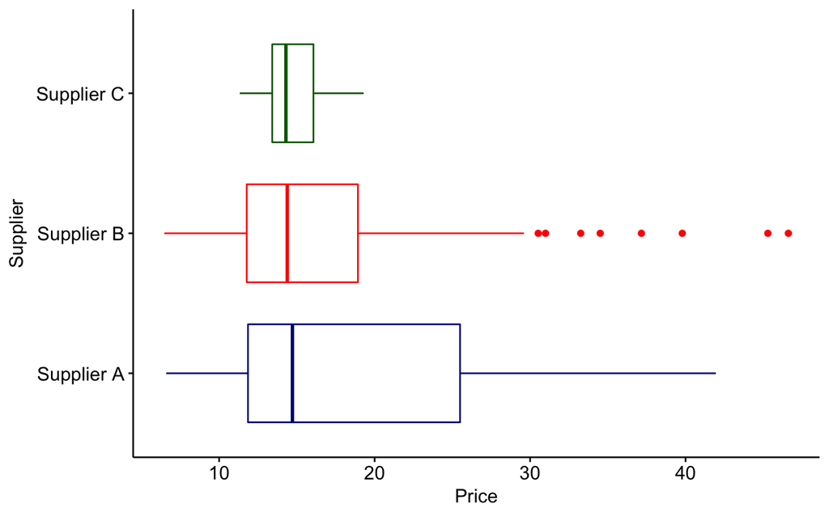

```r
supplier_plot_1 <- ggboxplot(raw_data,x="Supplier",y="Price",color = "Supplier", palette = c("darkblue","red","darkgreen"),legend="none") + rotate()
supplier_plot_2 <- ggscatter(raw_data,x="Length",y="Price",color = "Supplier", palette = c("darkblue","red","darkgreen"),xscale= "log10", yscale="log10")
supplier_plot_3 <- ggscatter(raw_data,x="weight",y="Price",color = "Supplier", palette = c("darkblue","red","darkgreen"),xscale= "log10", yscale="log10")
supplier_plot_4 <- ggscatter(raw_data,x="Diameter",y="Price",color = "Supplier", palette = c("darkblue","red","darkgreen"),xscale= "log10", yscale="log10")
supplier_statistics <- raw_data %>% group_by(Supplier) %>%  summarise( "Average Price" = mean(Price), "Average Length" = mean(Length),"Average weight" = mean(weight),"Average Diameter" = mean(Diameter),  "Average Price / Length" = mean(Price)/mean(Length), "Average Price / weight" = mean(Price)/mean(weight), "Average Price / Diameter" = mean(Price)/mean(Diameter))
supplier_plot_1
```

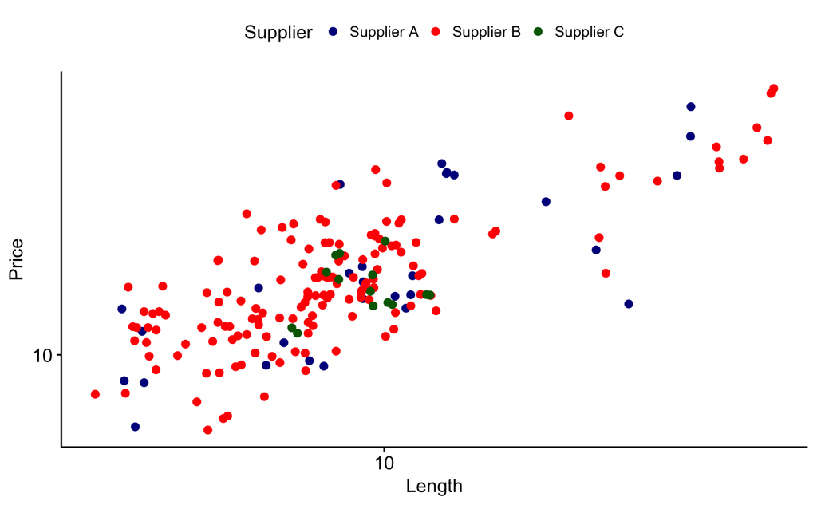

```r
supplier_plot_2
```

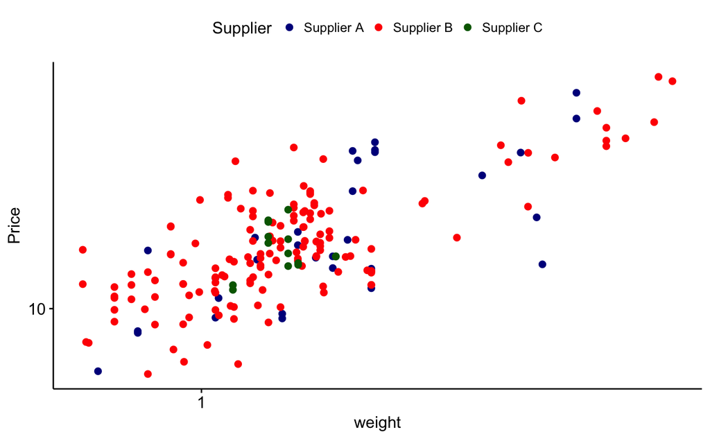

```r
supplier_plot_3
```

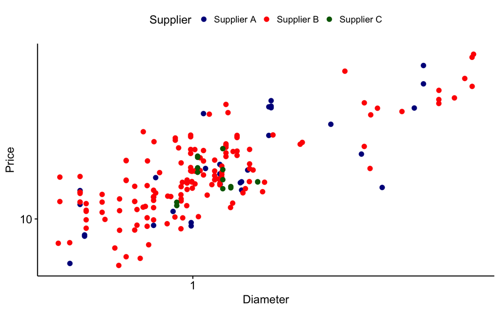

```r
supplier_plot_4
```

```r
head(supplier_statistics)
```

| Supplier | Average Price | Average Length | Average weight | Average Diameter | Average Price / Length | Average Price / weight | Average Price / Diameter |
| --- | --- | --- | --- | --- | --- | --- | --- |
| Supplier A | 18.02897 | 11.979042 | 2.000129 | 1.507903 | 1.505043 | 9.013902 | 11.95632 |
| Supplier B | 16.26141 | 9.977012 | 1.665581 | 1.250047 | 1.629888 | 9.763204 | 13.00864 |
| Supplier C | 14.88869 | 9.307535 | 1.414000 | 1.156000 | 1.599638 | 10.529484 | 12.87949 |

**3) One important point in explanatory data analysis consists in identifying potential outliers. Could you give points which are suspect regarding the Mature.Volume variable? Give the characteristics (other features) of the observations that seem suspsect**

There are four data points which seem suspect - they have the same characteristics for Diameter, weight, nb.of.pieces, Impermeability, Finishing, Raw.Material and Mature.Volume. They differ in their supplier, price and length. These suggest some error in collating the data (system error / default data).

```r
Mature.Volume_plot <- gghistogram(raw_data,x="Mature.Volume",y="..count..", color = "darkblue", fill = "lightgrey") + theme_minimal()
```

```
Using `bins = 30` by default. Pick better value with the argument `bins`.
```

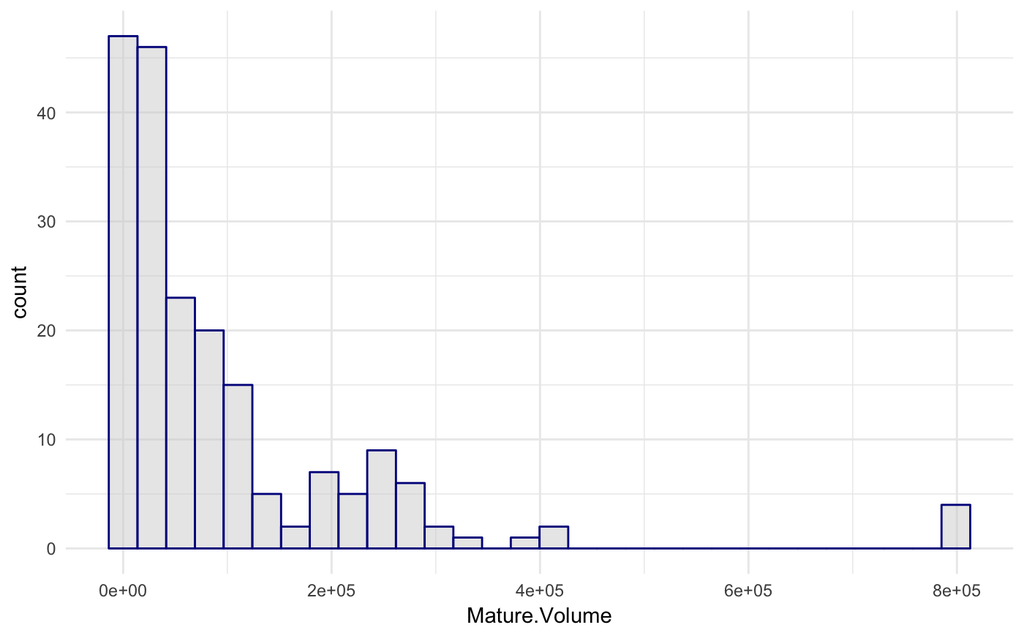

```r
Mature.Volume_plot
```

```r
raw_data %>% filter (Mature.Volume > 6e+05 )
```

| Supplier | Diameter | weight | nb.of.pieces | Shape | Impermeability | Finishing | Mature.Volume | Raw.Material | Price | Length |
| --- | --- | --- | --- | --- | --- | --- | --- | --- | --- | --- |
| Supplier A | 0.79 | 1.06 | 4 | Shape 1 | Type 1 | Lacquering | 800000 | PP | 12.256185 | 6.209053 |
| Supplier A | 0.79 | 1.06 | 4 | Shape 1 | Type 1 | Lacquering | 800000 | PP | 9.416743 | 6.412783 |
| Supplier B | 0.79 | 1.06 | 4 | Shape 1 | Type 1 | Lacquering | 800000 | PP | 11.113649 | 6.421937 |
| Supplier B | 0.79 | 1.06 | 4 | Shape 1 | Type 1 | Lacquering | 800000 | PP | 12.269223 | 6.212285 |

For the rest of the analysis, the 4 data points above are disregarded.

```r
library(dplyr)
raw_data <- raw_data %>% filter (Mature.Volume < 6e+05 )
```

**4) Perform a PCA on the dataset ScrewCap, explain briefly what are the aims of a PCA and how categorical variables are handled?**

Principal components analysis (PCA) is a technique for taking high-dimensional data, and using the dependencies between the variables to represent it in a more tractable, lower-dimensional form, without losing too much information - we try capture the essence of high dimentional data in a low dimensional representation. The aim of PCA is to draw conclusions from the linear relationships between variables by detecting the principal dimensions of variability. This may be for compression, denoising, data completion, anomaly detection or for preprocessing before supervised learning (improve performance / regularization to reduce overfitting).

The categorical variables cannot be represented in the same way as the supplementary quantitative variables since it is not possible to calculate the correlation between a categorical variable and the principal components. The categorical variables here are handled as supplemetary variables on a purely illustrative basis - they are not used to calculate the distance between inidividuals. We represent a categorical variable at the barycentre of all the individuals possessing that variable. A categorical variable on the PCA performed below can therefore be regarded as the mean individual obtained from the set of individuals who have it.

Given our ultimate goal here is to explore data prior to a multiple regression, it is advisable to choose the explanatory variables for the regression model as active variables for PCA, and to project the variable to be explained (the dependent variable) as a supplementary variable. This gives some idea of the relationships between explanatory variables and thus of the need to select explanatory variables. This also gives us an idea of the quality of the regression: if the dependent variable is appropriately projected, it will be a well-fitted model. Thus we select Price as a supplementary variable.

The dataset in this exercise contains 6 supplementary variables: - 1 quantitative variable (Price) - 5 qualitative variables (Supplier, Shape, Impermeability and Finishing).

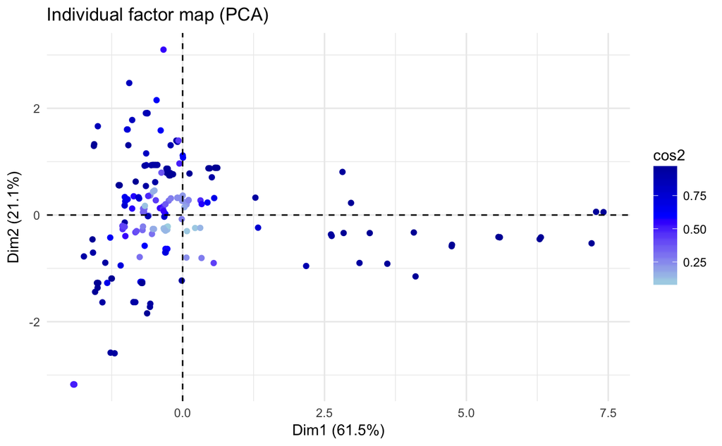

```r
res.pca <- PCA(raw_data,quali.sup = c(1,5,6,7,9),quanti.sup = 10, graph = FALSE)
fviz_pca_ind(res.pca, col.ind="cos2", label=c("quali"), geom = "point", title = "Individual factor map (PCA)", habillage = "none") + scale_color_gradient2(low="lightblue", mid="blue", high="darkblue", midpoint=0.6) + theme_minimal()
```

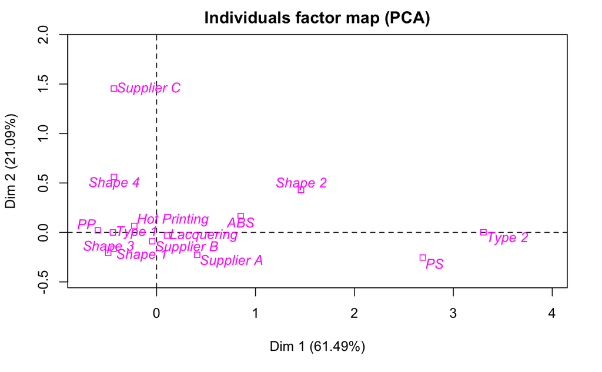

```r
plot.PCA(res.pca,choix = c("ind"),invisible = c("ind"))+theme_minimal()
```

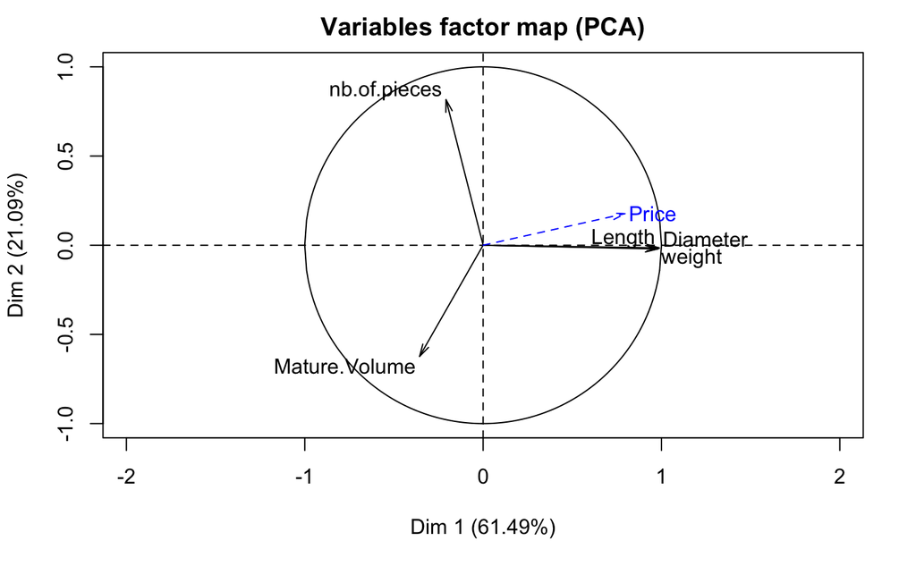

```r
plot.PCA(res.pca,choix = c("var"))+theme_minimal()
```

**5) Compute the correlation matrix between the variables and comment it with respect to the correlation circle**

The first task is to center and standardize the variables. Then the correlation matrix is computed. All variable vectors are quite near to the boundary of the correlation circle on the variables plot - thus the variables are relatively well projected on the 2 dimensional subspace. We now turn our attention to correlations between variables.

```r
don_correlation
```

```
                Diameter     weight nb.of.pieces Mature.Volume     Length
Diameter       1.0000000  0.9624561  -0.14742721   -0.24777035  0.9996960
weight         0.9624561  1.0000000  -0.16736670   -0.26659464  0.9629389
nb.of.pieces  -0.1474272 -0.1673667   1.00000000   -0.05820704 -0.1451257
Mature.Volume -0.2477703 -0.2665946  -0.05820704    1.00000000 -0.2487438
Length         0.9996960  0.9629389  -0.14512574   -0.24874382  1.0000000
```

**On what kind of relationship PCA focuses? Is it a problem?**

PCA focuses on the linear rela- tionships between variables. More complex links also exist, such as quadratic relationships, logarithmics, exponential functions, and so forth, but they are not studied in PCA. This may seem restrictive, but in practice many relation- ships can be considered linear, at least for an initial approximation.

**Comment the PCA outputs.** *Comment the position of the categories Impermeability=type 2 and Raw.Material=PS.* *Comment the percentage of inertia*

[figure not shown]

```r
fviz_nbclust(don, kmeans, method = "wss") + geom_vline(xintercept = 3, linetype = 2)
```

[output not shown]

The cluster 2 is made of individuals sharing : - high values for the variable nb.of.pieces. - low values for the variables Mature.Volume, Diameter, Length, weight and Price (variables are sorted from the weakest).

The cluster 3 is made of individuals such as 89, 90, 131, 161, 163 and 164. This group is characterized by : - high values for the variables Length, Diameter, weight and Price (variables are sorted from the strongest). - low values for the variables nb.of.pieces and Mature.Volume (variables are sorted from the weakest).

*If someone ask you why you have selected k components and not k + 1 or k − 1, what is your answer? (could you suggest a strategy to assess the stability of the approach? - are there many differences between the clustering obtained on k components or on the initial data)*

```r
res.pca <- PCA(raw_data,quali.sup = c(1,5,6,7,9),quanti.sup = 10,ncp=4)
res.hcpc <- HCPC(res.pca, nb.clust = -1)
res.pca <- PCA(raw_data,quali.sup = c(1,5,6,7,9),quanti.sup = 10,ncp=3)
res.hcpc <- HCPC(res.pca, nb.clust = -1)
res.pca <- PCA(raw_data,quali.sup = c(1,5,6,7,9),quanti.sup = 10,ncp=2)
res.hcpc <- HCPC(res.pca, nb.clust = -1)
```

[output not shown]

```r
res.hcpc <- HCPC(res.pca, nb.clust = -1, graph = FALSE)
```

```r
res.hcpc <- HCPC(res.pca, nb.clust = -1, graph = FALSE)
res.hcpc
plot.HCPC(res.hcpc, choice = 'map', draw.tree = FALSE, title = '', select=c("12"))


res.pca <- PCA(raw_data,quali.sup = c(1,5,6,7,9),quanti.sup = 10,ncp=3)
res.hcpc <- HCPC(res.pca, nb.clust = -1, graph = FALSE)
res.hcpc
```

[output not shown]

Characterization of each supplier

```r
catdes(raw_data, num.var=1)
catdes(raw_data, num.var=5)

catdes(raw_data, num.var=6)
```

[output not shown]

```r
res.famd <- FAMD (raw_data, ncp = 5, graph = TRUE, sup.var =  c(1,5,7,10), axes = c(1,2), row.w = NULL, tab.comp = NULL)


res.hcpc.famd <- HCPC(res.famd, nb.clust = -1
                , graph = TRUE)

plot.HCPC(res.hcpc.famd, choice = 'map', draw.tree = FALSE, select = c(1,10), title = '')
```

[output not shown]

```r
svm.model <- svm(Type~., data = raw_data[1:150,], cost = 100, gamma = 1)
```

[output not shown]